### ECE 225B: Universal Probability and Applications @UCSD

http://circuit.ucsd.edu/~yhk/ece225b-spr18/

# (Solutions) Homework 2: Mixture probability and context tree weighting

- **Due: May 23, 2018, 11:59 PM**
- Late homework will never be accepted.
- The homework will be collected through Gradescope. Please follow the submission instruction on Piazza.
- Please read the following problems carefully, and **write down your code as clearly as possible and add suitable comments.**
- **NAME**: Jongha Ryu (TA)
- **PID**:

In this homework, we will implement mixture probability assignments such as Krichevski-Trofimov (KT) and Laplace mixtures. Then, we will implement context tree weighting (CTW) using the KT probability assignment as a building block.

> [1] Willems, Frans MJ, Yuri M. Shtarkov, and Tjalling J. Tjalkens. **"The context-tree weighting method: basic properties."** *IEEE Transactions on Information Theory* 41.3 (1995): 653-664.

> [2] Willems, F. M., Tjalkens, T. J., and Ignatenko, T. (2006). **Context-tree weighting and maximizing: Processing betas.** *In Proceedings of Information Theory Applications Workshop*.

```python
import numpy as np
import matplotlib.pyplot as plt
%matplotlib inline
```

```python
# You may find this function useful
def chars_to_dict(chars):
    chars = sorted(list(set(chars)))
    char_to_index  = {x: i for i, x in enumerate(chars)}

    return char_to_index
```

```python
# CODES FROM HW1
def draw_one_sample_from(pmf):
    pmf = np.array(pmf)
    pmf = pmf / sum(pmf)
    return np.random.choice(range(len(pmf)), p=pmf)

def generate_mc(n, P, pinit=None):
    '''
    - n: length of output sequence
    - P: transition matrix
    - pinit: initial distribution
    '''
    x = np.zeros(n, dtype=np.int)
    log2_prob = 0
    if pinit is None:
        x[0] = np.random.randint(P.shape[0])
        p0 = 1/P.shape[0]
    else:
        x[0] = draw_one_sample_from(pinit)
        p0 = pinit[x[0]]
    log2_prob += np.log2(p0)

    for i in range((int(n)-1)):
        x[i+1] = draw_one_sample_from(P[x[i], :])
        log2_prob += np.log2(P[x[i],x[i+1]])

    return x, log2_prob

class Node(object):
    def __init__(self):
        self.data = None
        self.children = []

    def add_child(self):
        self.children.append(Node())

    def add_children(self, num_child):
        for _ in range(num_child):
            self.add_child()

def prob_LZ78_seq(string, char_to_index):
    """
    - string: str, a sequence to be parsed
    - char_to_index: dict, a dictionary which maps a character to its index
    """
    num_abc = len(char_to_index)
    dist_array = np.zeros((len(string)+1, num_abc))  # i-th row is the sequential distribution

    root = Node()
    root.add_children(num_abc)
    root.data = np.ones(num_abc)
    node = root

    for i in range(len(string)):
        dist_array[i] = node.data

        new_symbol_index = char_to_index[string[i]]
        next_node = node.children[new_symbol_index]
        node.data[new_symbol_index] += num_abc-1

        if next_node.children: # if next_node is not a leaf
            node = next_node

        else: # if next_node is a leaf
            next_node.add_children(num_abc)
            next_node.data = np.ones(num_abc)
            node = root

    dist_array[-1] = node.data # q_{LZ}(x_{n+1}|x^n)
    dist_array /= dist_array.sum(axis=1)[:, np.newaxis] # normalization

    return dist_array
```

```python
def process_abc(abc):
    if type(abc) is dict:
        char_to_index = abc
    elif type(abc) in [str, list, set]:
        char_to_index = chars_to_dict(abc)
    else:
        raise ValueError('Input a valid alphabet')

    return char_to_index
```

## Problem 1. (Mixture of i.i.d. probabilities)

In this problem, we implement a sequential probability assignment based on the mixture of i.i.d. multinomial distributions with respect to the prior $\text{Dirichlet}(\alpha,\ldots,\alpha)$. Recall that the sequential probability assignment for this mixture simply reduces to the *add-$\alpha$* estimator. For example, if $\alpha=1/2$, it becomes the KT mixture, and if $\alpha=1$, it becomes the Laplace mixture.

Write a function

```
prob_mixture_iid_seq(string, char_to_index, alpha=1/2)
```

which takes `string`, `char_to_index`, and `alpha` as inputs, and outputs the sequential distribution `dist_array`. Here, `alpha` is a `float` variable, the smoothing parameter.

```python
def prob_mixture_iid_seq(string, abc, alpha=1/2):
    char_to_index = process_abc(abc)
    x = [char_to_index[char] for char in string]
    cnts = np.zeros(len(abc)) + alpha
    dist_array = np.zeros((len(string)+1, len(abc)))

    for i in range(len(string)):
        dist_array[i] = cnts
        cnts[x[i]] += 1

    dist_array[-1] = cnts
    dist_array /= dist_array.sum(axis=1)[:, np.newaxis]  # normalization

    return dist_array
```

```python
A = '10111111'
B = '0010110111'
C = '00121212102101210'
D = 'AGTTTTCGTAACGTT'
```

```python
prob_mixture_iid_seq(A, '01', alpha=1/2)
```

```
array([[0.5       , 0.5       ],
       [0.25      , 0.75      ],
       [0.5       , 0.5       ],
       [0.375     , 0.625     ],
       [0.3       , 0.7       ],
       [0.25      , 0.75      ],
       [0.21428571, 0.78571429],
       [0.1875    , 0.8125    ],
       [0.16666667, 0.83333333]])
```

```python
prob_mixture_iid_seq(B, '01', alpha=1)
```

```
array([[0.5       , 0.5       ],
       [0.66666667, 0.33333333],
       [0.75      , 0.25      ],
       [0.6       , 0.4       ],
       [0.66666667, 0.33333333],
       [0.57142857, 0.42857143],
       [0.5       , 0.5       ],
       [0.55555556, 0.44444444],
       [0.5       , 0.5       ],
       [0.45454545, 0.54545455],
       [0.41666667, 0.58333333]])
```

```python
prob_mixture_iid_seq(B, '012', alpha=1/2)
```

```
array([[0.33333333, 0.33333333, 0.33333333],
       [0.6       , 0.2       , 0.2       ],
       [0.71428571, 0.14285714, 0.14285714],
       [0.55555556, 0.33333333, 0.11111111],
       [0.63636364, 0.27272727, 0.09090909],
       [0.53846154, 0.38461538, 0.07692308],
       [0.46666667, 0.46666667, 0.06666667],
       [0.52941176, 0.41176471, 0.05882353],
       [0.47368421, 0.47368421, 0.05263158],
       [0.42857143, 0.52380952, 0.04761905],
       [0.39130435, 0.56521739, 0.04347826]])
```

```python
prob_mixture_iid_seq(C, '012')
```

```
array([[0.33333333, 0.33333333, 0.33333333],
       [0.6       , 0.2       , 0.2       ],
       [0.71428571, 0.14285714, 0.14285714],
       [0.55555556, 0.33333333, 0.11111111],
       [0.45454545, 0.27272727, 0.27272727],
       [0.38461538, 0.38461538, 0.23076923],
       [0.33333333, 0.33333333, 0.33333333],
       [0.29411765, 0.41176471, 0.29411765],
       [0.26315789, 0.36842105, 0.36842105],
       [0.23809524, 0.42857143, 0.33333333],
       [0.30434783, 0.39130435, 0.30434783],
       [0.28      , 0.36      , 0.36      ],
       [0.25925926, 0.40740741, 0.33333333],
       [0.31034483, 0.37931034, 0.31034483],
       [0.29032258, 0.41935484, 0.29032258],
       [0.27272727, 0.39393939, 0.33333333],
       [0.25714286, 0.42857143, 0.31428571],
       [0.2972973 , 0.40540541, 0.2972973 ]])
```

```python
prob_mixture_iid_seq(D, 'AGTC')
```

```
array([[0.25      , 0.25      , 0.25      , 0.25      ],
       [0.5       , 0.16666667, 0.16666667, 0.16666667],
       [0.375     , 0.125     , 0.375     , 0.125     ],
       [0.3       , 0.1       , 0.3       , 0.3       ],
       [0.25      , 0.08333333, 0.25      , 0.41666667],
       [0.21428571, 0.07142857, 0.21428571, 0.5       ],
       [0.1875    , 0.0625    , 0.1875    , 0.5625    ],
       [0.16666667, 0.16666667, 0.16666667, 0.5       ],
       [0.15      , 0.15      , 0.25      , 0.45      ],
       [0.13636364, 0.13636364, 0.22727273, 0.5       ],
       [0.20833333, 0.125     , 0.20833333, 0.45833333],
       [0.26923077, 0.11538462, 0.19230769, 0.42307692],
       [0.25      , 0.17857143, 0.17857143, 0.39285714],
       [0.23333333, 0.16666667, 0.23333333, 0.36666667],
       [0.21875   , 0.15625   , 0.21875   , 0.40625   ],
       [0.20588235, 0.14705882, 0.20588235, 0.44117647]])
```

## Problem 2. (Mixture of Markov probabilities)

Now we implement a sequential probability assignment based on the mixture of $k$-th order Markov probabilities. More precisely, as we discussed in the class, given an initial state $s_1=x_{-k-1}^0$, we assign the following probability to a given string $x_1^n$: $$ q_{k,\alpha}(x^n|s_1) = \prod_{s\in \mathcal{X}^k}q_{\alpha}^s(x^n|s_1), $$ where $q_{\alpha}^s(x^n|s_1)$ is the add-$\alpha$ probability assingment for the substring of $x^n$ having a state $s\in\mathcal{X}^k$. In words, given a Markov order $k$, we simply decompose the given sequence into subsequences according to the Markov states of length $k$, and assign simple mixture probabilities for each substring. For simplicity, let us assume $s_1$ to be $k$ consecutive 0's given the alphabet is $\{0,1,\ldots,M-1\}$, and find the probability $q_{k,\alpha}(x^n|s_1)$.

Write a function

```
prob_mixture_markov_seq(string, char_to_index, alpha=1/2, k=0)
```

which takes `string`, `char_to_index`, `alpha`, `k` as inputs, and outputs the sequential distribution `dist_array` of the add-$\alpha$ probability of the input string $x^n$ with respect to the $k$-th order Markov model. Here, `k` is a `int` variable representing the Markov order.

```python
def prob_mixture_markov_seq(string, abc, alpha=1/2, k=0, init_state=None):
    if k == 0:
        return prob_mixture_iid_seq(string, abc, alpha=alpha)

    char_to_index = process_abc(abc)
    index_to_char = {v: key for key,v in char_to_index.items()}
    dist_array = np.zeros((len(string)+1, len(abc)))

    counter = {}  # key=state, value=counts
    suffix = index_to_char[0]*k if init_state is None else init_state

    for i in range(len(string)+1):
        counter[suffix] = counter.get(suffix, np.zeros(len(abc)) + alpha)
        dist_array[i] = counter[suffix]
        if i < len(string):
            counter[suffix][char_to_index[string[i]]] += 1
            suffix = suffix[1:] + string[i]

    dist_array /= dist_array.sum(axis=1)[:, np.newaxis] # normalization

    return dist_array
```

```python
A, prob_mixture_markov_seq(A, '012', alpha=1/2, k=0)
```

```
('10111111', array([[0.33333333, 0.33333333, 0.33333333],
        [0.2       , 0.6       , 0.2       ],
        [0.42857143, 0.42857143, 0.14285714],
        [0.33333333, 0.55555556, 0.11111111],
        [0.27272727, 0.63636364, 0.09090909],
        [0.23076923, 0.69230769, 0.07692308],
        [0.2       , 0.73333333, 0.06666667],
        [0.17647059, 0.76470588, 0.05882353],
        [0.15789474, 0.78947368, 0.05263158]]))
```

```python
A, prob_mixture_markov_seq(A, '012', alpha=1/2, k=1)
```

```
('10111111', array([[0.33333333, 0.33333333, 0.33333333],
        [0.33333333, 0.33333333, 0.33333333],
        [0.2       , 0.6       , 0.2       ],
        [0.6       , 0.2       , 0.2       ],
        [0.42857143, 0.42857143, 0.14285714],
        [0.33333333, 0.55555556, 0.11111111],
        [0.27272727, 0.63636364, 0.09090909],
        [0.23076923, 0.69230769, 0.07692308],
        [0.2       , 0.73333333, 0.06666667]]))
```

```python
A, prob_mixture_markov_seq(A, '012', alpha=1/2, k=2)
```

```
('10111111', array([[0.33333333, 0.33333333, 0.33333333],
        [0.33333333, 0.33333333, 0.33333333],
        [0.33333333, 0.33333333, 0.33333333],
        [0.6       , 0.2       , 0.2       ],
        [0.33333333, 0.33333333, 0.33333333],
        [0.2       , 0.6       , 0.2       ],
        [0.14285714, 0.71428571, 0.14285714],
        [0.11111111, 0.77777778, 0.11111111],
        [0.09090909, 0.81818182, 0.09090909]]))
```

```python
B, prob_mixture_markov_seq(B, '01', alpha=1/2, k=1)
```

```
('0010110111', array([[0.5       , 0.5       ],
        [0.75      , 0.25      ],
        [0.83333333, 0.16666667],
        [0.5       , 0.5       ],
        [0.625     , 0.375     ],
        [0.75      , 0.25      ],
        [0.5       , 0.5       ],
        [0.5       , 0.5       ],
        [0.625     , 0.375     ],
        [0.5       , 0.5       ],
        [0.41666667, 0.58333333]]))
```

```python
B, prob_mixture_markov_seq(B, '012', alpha=1/2, k=2)
```

```
('0010110111', array([[0.33333333, 0.33333333, 0.33333333],
        [0.6       , 0.2       , 0.2       ],
        [0.71428571, 0.14285714, 0.14285714],
        [0.33333333, 0.33333333, 0.33333333],
        [0.33333333, 0.33333333, 0.33333333],
        [0.6       , 0.2       , 0.2       ],
        [0.33333333, 0.33333333, 0.33333333],
        [0.2       , 0.6       , 0.2       ],
        [0.42857143, 0.42857143, 0.14285714],
        [0.6       , 0.2       , 0.2       ],
        [0.42857143, 0.42857143, 0.14285714]]))
```

```python
C, prob_mixture_markov_seq(C, '012', alpha=1/2, k=3)
```

```
('00121212102101210', array([[0.33333333, 0.33333333, 0.33333333],
        [0.6       , 0.2       , 0.2       ],
        [0.71428571, 0.14285714, 0.14285714],
        [0.33333333, 0.33333333, 0.33333333],
        [0.33333333, 0.33333333, 0.33333333],
        [0.33333333, 0.33333333, 0.33333333],
        [0.33333333, 0.33333333, 0.33333333],
        [0.2       , 0.2       , 0.6       ],
        [0.2       , 0.6       , 0.2       ],
        [0.14285714, 0.14285714, 0.71428571],
        [0.33333333, 0.33333333, 0.33333333],
        [0.33333333, 0.33333333, 0.33333333],
        [0.33333333, 0.33333333, 0.33333333],
        [0.2       , 0.2       , 0.6       ],
        [0.33333333, 0.33333333, 0.33333333],
        [0.2       , 0.6       , 0.2       ],
        [0.33333333, 0.11111111, 0.55555556],
        [0.14285714, 0.42857143, 0.42857143]]))
```

```python
C, prob_mixture_markov_seq(C, '012', alpha=1/2, k=5)
```

```
('00121212102101210', array([[0.33333333, 0.33333333, 0.33333333],
        [0.6       , 0.2       , 0.2       ],
        [0.71428571, 0.14285714, 0.14285714],
        [0.33333333, 0.33333333, 0.33333333],
        [0.33333333, 0.33333333, 0.33333333],
        [0.33333333, 0.33333333, 0.33333333],
        [0.33333333, 0.33333333, 0.33333333],
        [0.33333333, 0.33333333, 0.33333333],
        [0.33333333, 0.33333333, 0.33333333],
        [0.2       , 0.2       , 0.6       ],
        [0.33333333, 0.33333333, 0.33333333],
        [0.33333333, 0.33333333, 0.33333333],
        [0.33333333, 0.33333333, 0.33333333],
        [0.33333333, 0.33333333, 0.33333333],
        [0.33333333, 0.33333333, 0.33333333],
        [0.33333333, 0.33333333, 0.33333333],
        [0.33333333, 0.33333333, 0.33333333],
        [0.33333333, 0.33333333, 0.33333333]]))
```

## Problem 3. (Context tree weighting)

We implement context tree weighting algorithm in this problem. Recall that $$ q^s_{\text{CTW}}(x^n)= \begin{cases} \displaystyle\frac{1}{2}q^s_{\text{KT}}(x^n) +\frac{1}{2}\prod_{y\in \mathcal{X}}q^{ys}_{\text{CTW}}(x^n) &\text{if }|s|<k\\ \displaystyle q^s_{\text{KT}}(x^n) &\text{if }|s|=k \end{cases} $$

Write a function

```
prob_ctw_seq(string, chars)
```

that outputs a sequential distribution `dist_array` produced by CTW.

### NOTE: How to implement conditional probability efficiently?

Note that a naive implementation of sequential probability assignment \begin{align} q^{\lambda}_{\text{CTW}}(\alpha|x^n) = \frac{q^{\lambda}_{\text{CTW}}(x^n\alpha)}{q^{\lambda}_{\text{CTW}}(x^n)} \end{align} for each $\alpha\in\mathcal{X}$ using the above recursion would be really slow.

The following is a summary of Section 2 of [2], which allows us a much faster implementation.

For a given maximum depth $D$, let us assume that we are given a suffix $s_1=x_{-D-1}^{0}$, and omit the conditioning for simplicity. That is, we write $q^{\lambda}_{\text{CTW}}(\alpha|x^n)=q^{\lambda}_{\text{CTW}}(\alpha|x_{-D-1}^0x_1^n)$.

#### Algorithm

For each $n=0,1,\ldots,N$, we would like to find $q_{\text{CTW}}^{\lambda}(\cdot|x^n)$, where $\lambda$ denotes the empty string. Suppose $|s|<D$. From the recursion formula, we can write \begin{align} q_{\text{CTW}}^s(\alpha|x^n) &=\frac{q_{\text{CTW}}^s(x^n\alpha)}{q_{\text{CTW}}^s(x^n)}\\ &=\frac{q^s_{\text{KT}}(x^n\alpha)+\prod_{y\in \mathcal{X}}q^{ys}_{\text{CTW}}(x^n\alpha)}{q^s_{\text{KT}}(x^n)+\prod_{y\in \mathcal{X}}q^{ys}_{\text{CTW}}(x^n)}\\ &=\frac{\beta^s(x^n)q_{\text{KT}}^s(\alpha|x^n)+q_{\text{CTW}}^{x_{n-|s|}~ ~ ~s}(\alpha|x^n)}{\beta^s(x^n)+1}, && (\because q^{ys}_{\text{CTW}}(x^n\alpha)=q^{ys}_{\text{CTW}}(x^n) \text{ if } y\neq x_{n-|s|}) \end{align} where $\beta^s(x^n)$ is defined as the ratio $$ \beta^s(x^n)=\frac{q_{\text{KT}}^s(x^n)}{\prod_{y\in\mathcal{X}}q_{\text{CTW}}^{ys}(x^n)}. $$ Hence, $q_{\text{CTW}}^{\lambda}(\cdot|x^n)$ can be found recursively as follows: $$ \begin{align} q_{\text{CTW}}^s(\cdot|x^n)= \begin{cases} \displaystyle\frac{\beta^s(x^n)q_{\text{KT}}^s(\cdot|x^n)+q_{\text{CTW}}^{x_{n-|s|}~ ~ ~s}(\cdot|x^n)}{\beta^s(x^n)+1} & \text{if }|s|<D\\ q_{\text{KT}}^s(\cdot|x^n) & \text{if }|s|=D \end{cases}, \end{align} $$ After obtaining the conditional distribution, the ratio $\beta^s(\cdot)$ for each $s$ needs to be updated with the new symbol $x_{n+1}$ if $n\le N-1$ as follows: \begin{align} \beta^s(x^nx_{n+1}) = \beta^s(x^n) \frac{q_{\text{KT}}^s(x_{n+1}|x^n)}{q_{\text{CTW}}^{x_{n-|s|}~ ~ ~s}(x_{n+1}|x^n)}, &&\text{if }|s|<D. \end{align}

#### Implementation

To implement this, use any tree data structure storing the counter of the symbols and the ratio $\beta^s$ for each node $s$.

We extend the existing ```Node``` class to make the CTW implementation easier.

```python
class NodeCTW(Node):
    def __init__(self, num_abc, depth=0, alpha=1/2):
        Node.__init__(self)
        self.depth = depth
        self.alpha = alpha
        self.num_abc = num_abc
        self.data = {'counter': np.zeros(num_abc)+alpha, 'log2beta': 0}

    def add_child(self):
        self.children.append(NodeCTW(self.num_abc, depth=self.depth+1, alpha=self.alpha))

    def add_children(self):
        Node.add_children(self, self.num_abc)
```

```python
def prob_ctw_seq(string, abc, alpha=1/2, max_depth=5, init_state=None):
    """
    - string: str, a sequence to be parsed
    - char_to_index: dict, a dictionary which maps a character to its index
    """
    char_to_index = process_abc(abc)
    abc_size = len(char_to_index)
    x = [char_to_index[char] for char in string]  # convert a string into a list of indices
    dist_array = np.zeros((len(x)+1, abc_size))   # i-th row is the sequential distribution

    root = NodeCTW(abc_size, depth=0, alpha=alpha)
    suffix = [0] * max_depth if init_state is None else init_state # initial conditioning

    for i in range(len(x)+1):
        new_symbol = x[i] if i < len(x) else None
        dist_array[i] = prob_ctw_seq_recursion(root, suffix, new_symbol=new_symbol)
        if max_depth > 0:
            suffix = suffix[1:] + [new_symbol]

    return dist_array
```

```python
def prob_ctw_seq_recursion(node, suffix, new_symbol=None):
    # suffix has the length of max_depth
    assert node.depth <= len(suffix)

    qKT_node_cond = node.data['counter']/node.data['counter'].sum()
    if new_symbol is not None:
        node.data['counter'][new_symbol] += 1

    if node.depth == len(suffix):
        return qKT_node_cond
    else:
        if not node.children:
            node.add_children()

        # 1) Find the next symbol conditional distribution
        next_suffix_symbol = suffix[-node.depth-1]  # equivalent to the child node
        qCTW_child_node_dist = prob_ctw_seq_recursion(node.children[next_suffix_symbol], suffix, new_symbol=new_symbol)
        beta = 2**node.data['log2beta']
        qCTW_node_cond = (beta*qKT_node_cond + qCTW_child_node_dist)/(beta+1)

        # 2) Update the beta if there is new_symbol
        if new_symbol is not None:
            node.data['log2beta'] += np.log2(qKT_node_cond[new_symbol]/qCTW_child_node_dist[new_symbol])

        return qCTW_node_cond
```

```python
prob_mixture_iid_seq(A, '01', alpha=1/2)
```

```
array([[0.5       , 0.5       ],
       [0.25      , 0.75      ],
       [0.5       , 0.5       ],
       [0.375     , 0.625     ],
       [0.3       , 0.7       ],
       [0.25      , 0.75      ],
       [0.21428571, 0.78571429],
       [0.1875    , 0.8125    ],
       [0.16666667, 0.83333333]])
```

```python
prob_ctw_seq(A, '01', max_depth=0)
```

```
array([[0.5       , 0.5       ],
       [0.25      , 0.75      ],
       [0.5       , 0.5       ],
       [0.375     , 0.625     ],
       [0.3       , 0.7       ],
       [0.25      , 0.75      ],
       [0.21428571, 0.78571429],
       [0.1875    , 0.8125    ],
       [0.16666667, 0.83333333]])
```

```python
prob_ctw_seq(A, '01', max_depth=1)
```

```
array([[0.5       , 0.5       ],
       [0.375     , 0.625     ],
       [0.33333333, 0.66666667],
       [0.65625   , 0.34375   ],
       [0.40909091, 0.59090909],
       [0.30769231, 0.69230769],
       [0.25      , 0.75      ],
       [0.21180556, 0.78819444],
       [0.18428781, 0.81571219]])
```

```python
prob_ctw_seq(A, '01', max_depth=2)
```

```
array([[0.5       , 0.5       ],
       [0.375     , 0.625     ],
       [0.41666667, 0.58333333],
       [0.64285714, 0.35714286],
       [0.4       , 0.6       ],
       [0.27604167, 0.72395833],
       [0.21942446, 0.78057554],
       [0.18317972, 0.81682028],
       [0.15726375, 0.84273625]])
```

```python
prob_ctw_seq(A, '01', max_depth=5)
```

```
array([[0.5       , 0.5       ],
       [0.375     , 0.625     ],
       [0.41666667, 0.58333333],
       [0.59821429, 0.40178571],
       [0.41111111, 0.58888889],
       [0.30896226, 0.69103774],
       [0.23805461, 0.76194539],
       [0.19204927, 0.80795073],
       [0.16016979, 0.83983021]])
```

```python
prob_ctw_seq(B, '01', max_depth=2)
```

```
array([[0.5       , 0.5       ],
       [0.75      , 0.25      ],
       [0.83333333, 0.16666667],
       [0.5625    , 0.4375    ],
       [0.63888889, 0.36111111],
       [0.67307692, 0.32692308],
       [0.5       , 0.5       ],
       [0.47794118, 0.52205882],
       [0.53169014, 0.46830986],
       [0.54135338, 0.45864662],
       [0.42418033, 0.57581967]])
```

```python
prob_ctw_seq(B, '01', max_depth=5)
```

```
array([[0.5       , 0.5       ],
       [0.75      , 0.25      ],
       [0.83333333, 0.16666667],
       [0.5625    , 0.4375    ],
       [0.63888889, 0.36111111],
       [0.63942308, 0.36057692],
       [0.5       , 0.5       ],
       [0.5       , 0.5       ],
       [0.5       , 0.5       ],
       [0.55833333, 0.44166667],
       [0.43207547, 0.56792453]])
```

```python
prob_ctw_seq(B, '012', max_depth=5)
```

```
array([[0.33333333, 0.33333333, 0.33333333],
       [0.6       , 0.2       , 0.2       ],
       [0.71428571, 0.14285714, 0.14285714],
       [0.44444444, 0.33333333, 0.22222222],
       [0.56439394, 0.29545455, 0.14015152],
       [0.53629191, 0.32061144, 0.14309665],
       [0.43818019, 0.43818019, 0.12363961],
       [0.48503079, 0.42460566, 0.09036355],
       [0.46390453, 0.45094078, 0.08515469],
       [0.45137422, 0.47190338, 0.0767224 ],
       [0.38970028, 0.54998224, 0.06031749]])
```

```python
prob_ctw_seq(D, 'AGTC', max_depth=1)
```

```
array([[0.25      , 0.25      , 0.25      , 0.25      ],
       [0.5       , 0.16666667, 0.16666667, 0.16666667],
       [0.3125    , 0.1875    , 0.3125    , 0.1875    ],
       [0.26666667, 0.2       , 0.26666667, 0.26666667],
       [0.19791667, 0.13541667, 0.19791667, 0.46875   ],
       [0.1547619 , 0.10714286, 0.1547619 , 0.58333333],
       [0.125     , 0.08928571, 0.125     , 0.66071429],
       [0.23333333, 0.23333333, 0.23333333, 0.3       ],
       [0.16428571, 0.16428571, 0.17857143, 0.49285714],
       [0.09025033, 0.23517787, 0.10210804, 0.57246377],
       [0.34215328, 0.125     , 0.34215328, 0.19069343],
       [0.47230769, 0.10184615, 0.28707692, 0.13876923],
       [0.17799597, 0.16828514, 0.45630125, 0.19741764],
       [0.13076377, 0.12721684, 0.13076377, 0.61125562],
       [0.21442819, 0.21243351, 0.07613032, 0.49700798],
       [0.18797954, 0.18644501, 0.06624041, 0.55933504]])
```

## Problem 4. (Minimax mean universality of mixtures)

In this problem, we will verify universality and compare the speed of convergence of the mixture strategies. As previously in **Homework #1**, we would like to verify that $$ \lim_{n\to\infty}\mathbb{E}_{X^n\sim \mathsf{P}}\left[\log_2\frac{p(X^n)}{q(X^n)}\right]=0 $$ for some distribution $\mathsf{P}$.

To verify this, we draw $n$ independent random variables $X^n(i)\sim \mathsf{P}$ independently for $i=1,\ldots,N$ to obtain $$ \frac{1}{N}\sum_{i=1}^N \log_2\frac{p(X^n(i))}{q(X^n(i))}\approx \mathbb{E}_{X^n\sim \mathsf{P}}\left[\log\frac{p(X^n)}{q(X^n)}\right]. $$ We will consider the following two simple probability model classes.

> a) $\mathcal{P_a}$={a Bernoulli($p$) i.i.d. process $X_i\sim \text{Bern}(p)$: $p\in[0,1]$}

> b) $\mathcal{P_b}$={a binary symmetric Markov chain $X^n$ of transition matrix $$ P=\begin{bmatrix} 1-p & p\\ p & 1-p \end{bmatrix}, $$ starting from the initial distribution $\pi=[1/2,1/2]$: $p\in[0,1]$}

### Problem 4(a).

For the class of Bernoulli processes $\mathcal{P_a}$, find the **approximate** mean minimax redundancy $$ \frac{1}{n}\max_{p\in \{0.02,0.04,\ldots,0.5\}}\frac{1}{N}\sum_{i=1}^N \log_2\frac{p(X^n{(i)})}{q(X^n{(i)})} $$ for KT and Laplace mixture of $k$-th Markov order probabilities ($k\in\{0,1,2\}$), LZ probability assignment, CTW with max_depth$\in\{1,2\}$, for $n\in \{10, 50, 100, 500, 1000, 5000\}$, while fixing $N=50$.

Plot $\log_{10} n$ vs. $\log_{10}$ of the approximate mean minimax redundancy curve for each probability assignment in the same plot. There should be 9 curves in the same plot. Which probability assignment gives the fastest convergence rate?

### Problem 4(c).

For the class of binary symmetric Markov processes $\mathcal{P_b}$, repeat the same experiment in **Problem 4(a)**.

```python
%pylab inline
pylab.rcParams['figure.figsize'] = (15, 6)
```

```python
def log2_prob(string, char_to_index, prob_assign_seq_func):
    """
    - string: str, a sequence to be parsed
    - char_to_index: dict, a dictionary which maps a character to its index
    - prob_assign_seq: a function takes string, and char_to_index as inputs
    """
    dist_array = prob_assign_seq_func(string, char_to_index)
    log2prob = np.sum([np.log2(dist_array[i, char_to_index[string[i]]]) for i in range(len(string))])

    return log2prob
```

```python
def log2_prob_mixture_markov(string, char_to_index, alpha=1/2, k=1):
    return log2_prob(string, char_to_index, lambda x, y: prob_mixture_markov_seq(x, y, alpha=alpha, k=k))
```

```python
def log2_prob_CTW(string, char_to_index, max_depth=5):
    return log2_prob(string, char_to_index, lambda x, y: prob_ctw_seq(x, y, max_depth=max_depth))
```

```python
def log2_prob_LZ78(string, char_to_index):
    return log2_prob(string, char_to_index, prob_LZ78_seq)
```

```python
def mean_redundancy(log2_prob_assign_func, nlist, plist, N=50, model="iid"):
    M = 2  # let's focus on the binary alphabet
    red_array = np.zeros((len(plist), len(nlist)))

    for i, p in enumerate(plist):
        print('model={}, {}-th p={}'.format(model,i+1,p))
        if model == "iid":
            P = np.array([[1-p, p], [1-p, p]])
            pinit = [1-p, p]
        elif model == "bsmc":
            P = np.array([[1-p, p], [p, 1-p]])
            pinit = None
        else:
            raise ValueError("Input a valid model class either 'iid' or 'bsmc'")

        for j, n in enumerate(nlist):

            redundancy = 0
            for __ in range(N):
                x, log2prob = generate_mc(n, P, pinit)
                xstr = ''.join([str(xi) for xi in x])
                log2prob_assigned = log2_prob_assign_func(xstr, chars_to_dict([str(k) for k in range(M)]))
                redundancy += log2prob - log2prob_assigned
            red_array[i,j] = redundancy/N/n

    return red_array
```

```python
%%time
nlist = [10, 50, 100, 500, 1000, 5000]
plist = np.arange(0.02, 0.51, 0.02)
model_list = ["iid", "bsmc"]

prob_assignment_name_list = ["Markov(k=0), KT",
                             "Markov(k=1), KT",
                             "Markov(k=2), KT",
                             "Markov(k=0), Laplace",
                             "Markov(k=1), Laplace",
                             "Markov(k=2), Laplace",
                             "Lempel-Ziv",
                             "CTW(depth=1)",
                             "CTW(depth=2)"]

log2_prob_assignment_func_list = [lambda x,y: log2_prob_mixture_markov(x,y,k=0,alpha=1/2),
                                  lambda x,y: log2_prob_mixture_markov(x,y,k=1,alpha=1/2),
                                  lambda x,y: log2_prob_mixture_markov(x,y,k=2,alpha=1/2),
                                  lambda x,y: log2_prob_mixture_markov(x,y,k=0,alpha=1),
                                  lambda x,y: log2_prob_mixture_markov(x,y,k=1,alpha=1),
                                  lambda x,y: log2_prob_mixture_markov(x,y,k=2,alpha=1),
                                  log2_prob_LZ78,
                                  lambda x,y: log2_prob_CTW(x,y,max_depth=1),
                                  lambda x,y: log2_prob_CTW(x,y,max_depth=2)]
red_array_dict = {}
for model in model_list:
    red_array_dict[model] = [np.zeros((len(plist), len(nlist))) for __ in range(len(log2_prob_assignment_func_list))]
    for i, log2_prob_assignment in enumerate(log2_prob_assignment_func_list):
        print(model, prob_assignment_name_list[i])
        red_array_dict[model][i] = mean_redundancy(log2_prob_assignment, nlist, plist, N=5, model=model)
```

[output not shown]

[output cut: 414 more lines]

```
model=bsmc, 12-th p=0.24
model=bsmc, 13-th p=0.26
model=bsmc, 14-th p=0.28
model=bsmc, 15-th p=0.30000000000000004
model=bsmc, 16-th p=0.32
model=bsmc, 17-th p=0.34
model=bsmc, 18-th p=0.36000000000000004
model=bsmc, 19-th p=0.38
model=bsmc, 20-th p=0.4
model=bsmc, 21-th p=0.42000000000000004
model=bsmc, 22-th p=0.44
model=bsmc, 23-th p=0.46
model=bsmc, 24-th p=0.48000000000000004
model=bsmc, 25-th p=0.5
Wall time: 12min 4s
```

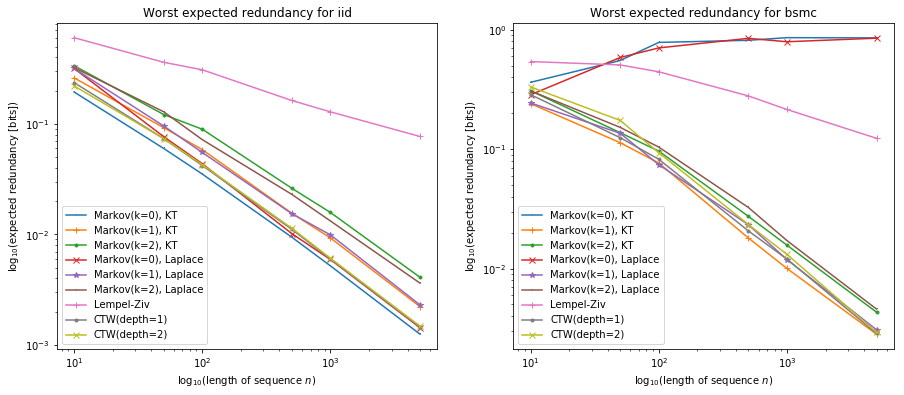

```python
import itertools

for i, model in enumerate(model_list):
    plt.subplot(1,2,i+1)
    markers = itertools.cycle((',', '+', '.', 'x', '*'))
    for j in range(len(red_array_dict[model])):
        plt.loglog(nlist, red_array_dict[model][j].max(axis=0),
                   marker=next(markers),
                   label=prob_assignment_name_list[j])
    plt.legend(loc=3)

    plt.title('Worst expected redundancy for '+model)
    plt.xlabel('$\log_{10}$(length of sequence $n$)')
    plt.ylabel('$\log_{10}$(expected redundancy [bits])')
```

### Problem 4(b).

For each $n\in \{500, 1000, 5000\}$, find the approximate mean minimax redundancy for each add-$\alpha$ mixtures for $\alpha\in\{0.1,0.2,\ldots, 2.9,3\}$, and plot the values with respect to $\alpha$. There should be 3 curves in the same plot. Which $\alpha$ does achive the minimum mean minimax redundancy?

```python
%%time
nlist = [500, 1000, 5000]
plist = plist = np.arange(0.02, 0.51, 0.04)
alpha_list = list(np.arange(0.1, 3, 0.1))

red_array_dict = {}
for model in model_list:
    red_array_dict[model] = np.zeros((len(alpha_list), len(nlist)))
    for i, alpha in enumerate(alpha_list):
        if model is "iid":
            log2_prob_assignment_func = lambda x,y: log2_prob_mixture_markov(x,y,k=0,alpha=alpha)
        else:
            log2_prob_assignment_func = lambda x,y: log2_prob_mixture_markov(x,y,k=1,alpha=alpha)
        red_array_dict[model][i, :] = mean_redundancy(log2_prob_assignment_func,
                                                      nlist, plist, N=10, model=model).max(axis=0)
```

[output not shown]

[output cut: 700 more lines]

```
model=bsmc, 13-th p=0.49999999999999994
model=bsmc, 1-th p=0.02
model=bsmc, 2-th p=0.06
model=bsmc, 3-th p=0.09999999999999999
model=bsmc, 4-th p=0.13999999999999999
model=bsmc, 5-th p=0.17999999999999997
model=bsmc, 6-th p=0.21999999999999995
model=bsmc, 7-th p=0.25999999999999995
model=bsmc, 8-th p=0.3
model=bsmc, 9-th p=0.33999999999999997
model=bsmc, 10-th p=0.37999999999999995
model=bsmc, 11-th p=0.41999999999999993
model=bsmc, 12-th p=0.45999999999999996
model=bsmc, 13-th p=0.49999999999999994
Wall time: 35min 3s
```

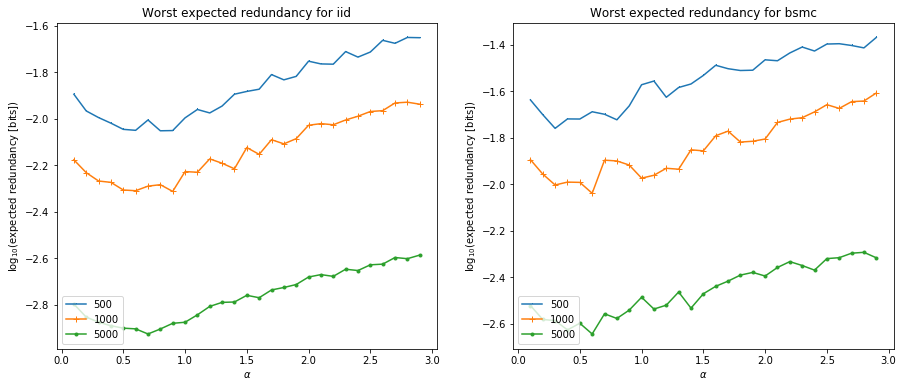

```python
for i, model in enumerate(model_list):
    plt.subplot(1,2,i+1)
    plt.title('Worst expected redundancy for '+model)
    plt.xlabel(r'$\alpha$')
    plt.ylabel('$\log_{10}$(expected redundancy [bits])')
    markers = itertools.cycle((',', '+', '.', 'x', '*'))
    for j in range(len(nlist)):
        plt.plot(alpha_list, np.log10(red_array_dict[model][:, j]),
                 marker=next(markers),
                 label=nlist[j])
    plt.legend(loc=3)
```

Note that the right plot has been obtained with the Markov mixture of order $k=1$.

## Problem 5. (Universal compression with CTW)

In this problem, we compress the same data in **Homework #1**.

- For each dataset, compare the compression ratio with the number from **Homework #1**. Does CTW compress better than LZ?
- For `max_depth`, use 5 or 10. Considering time complexity, what would be a good choice in practice?

```python
from arithmetic_enc_public import *
```

```python
def compress_with_CTW(filename, char_to_index=None, max_depth=5, verbose=False):
    file = open(filename, 'r', encoding="utf8")
    string = file.read()
    file.close()
    if char_to_index is None:
        char_to_index = chars_to_dict(string)

    dist_array = prob_ctw_seq(string, char_to_index, max_depth=max_depth)
    encoded_bits = arithmetic_enc_offline(string, char_to_index, dist_array)

    if verbose:
        compress_ratio = len(encoded_bits) / (len(string) * np.log2(len(char_to_index)))
        print("The compression ratio is {}%.".format(compress_ratio*100))

    return compress_ratio
```

### Problem 5(a). Genome sequence

```python
filename = 'data/CElegans_sample.txt'
alphabet = 'AGTC'
max_depth_list = range(20)
compress_ratio_list = np.zeros(len(max_depth_list))
for i, max_depth in enumerate(max_depth_list):
    print("# For max_depth={}".format(max_depth))
    print("\tFilename '{}': ".format(filename), end = '')
    %time compress_ratio_list[i] = compress_with_CTW(filename, chars_to_dict(alphabet),\
                                                     max_depth=max_depth, verbose=True);
```

```
# For max_depth=0
	Filename 'data/CElegans_sample.txt': The compression ratio is 97.3%.
Wall time: 50.8 ms
# For max_depth=1
	Filename 'data/CElegans_sample.txt': The compression ratio is 91.14999999999999%.
Wall time: 85.8 ms
# For max_depth=2
	Filename 'data/CElegans_sample.txt': The compression ratio is 81.15%.
Wall time: 98.7 ms
# For max_depth=3
	Filename 'data/CElegans_sample.txt': The compression ratio is 74.3%.
Wall time: 123 ms
# For max_depth=4
	Filename 'data/CElegans_sample.txt': The compression ratio is 71.025%.
Wall time: 151 ms
# For max_depth=5
	Filename 'data/CElegans_sample.txt': The compression ratio is 69.55%.
Wall time: 178 ms
# For max_depth=6
	Filename 'data/CElegans_sample.txt': The compression ratio is 69.25%.
Wall time: 265 ms
# For max_depth=7
	Filename 'data/CElegans_sample.txt': The compression ratio is 69.1%.
Wall time: 262 ms
# For max_depth=8
	Filename 'data/CElegans_sample.txt': The compression ratio is 69.075%.
Wall time: 310 ms
# For max_depth=9
	Filename 'data/CElegans_sample.txt': The compression ratio is 69.1%.
Wall time: 386 ms
# For max_depth=10
	Filename 'data/CElegans_sample.txt': The compression ratio is 69.075%.
Wall time: 429 ms
# For max_depth=11
	Filename 'data/CElegans_sample.txt': The compression ratio is 69.075%.
Wall time: 475 ms
# For max_depth=12
	Filename 'data/CElegans_sample.txt': The compression ratio is 69.1%.
Wall time: 550 ms
# For max_depth=13
	Filename 'data/CElegans_sample.txt': The compression ratio is 69.1%.
Wall time: 617 ms
# For max_depth=14
	Filename 'data/CElegans_sample.txt': The compression ratio is 69.075%.
Wall time: 670 ms
# For max_depth=15
	Filename 'data/CElegans_sample.txt': The compression ratio is 69.1%.
Wall time: 868 ms
# For max_depth=16
	Filename 'data/CElegans_sample.txt': The compression ratio is 69.1%.
Wall time: 827 ms
# For max_depth=17
	Filename 'data/CElegans_sample.txt': The compression ratio is 69.1%.
Wall time: 868 ms
# For max_depth=18
	Filename 'data/CElegans_sample.txt': The compression ratio is 69.05%.
Wall time: 1.01 s
# For max_depth=19
	Filename 'data/CElegans_sample.txt': The compression ratio is 69.075%.
Wall time: 1.07 s
```

```
Text(0,0.5,'compression ratio')
```

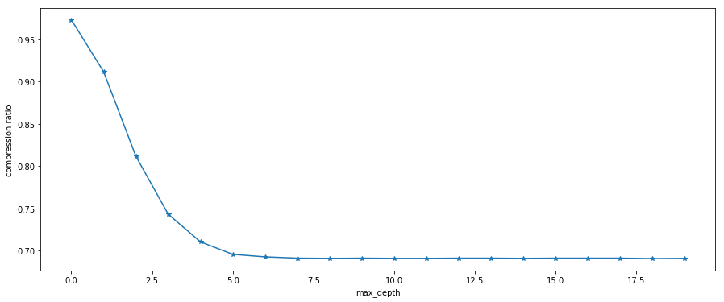

```python
plt.plot(max_depth_list, compress_ratio_list, marker='*')
plt.xlabel('max_depth')
plt.ylabel('compression ratio')
```

The minimum compression ratio can be (almost) achieved with max_depth = 5.

### Problem 5(b). The Little Prince

```python
nums = {'0', '1', '2', '3', '4', '5', '6', '7', '8', '9'}
en_abc = {' ', 'a', 'b', 'c', 'd', 'e', 'f', 'g', 'h', 'i', 'j', 'k', 'l', 'm', 'n',
          'o', 'p', 'q', 'r', 's', 't', 'u', 'v', 'w', 'x', 'y', 'z'}
fr_letters = {'é',
              'à', 'è', 'ù',
              'â', 'ê', 'î', 'ô', 'û',
              'ç',
              'ë', 'ï', 'ü'}
```

```python
filename_list = ['data/sample_the_little_prince_en.txt',
                 'data/sample_the_little_prince_fr.txt']
alphabet_list = [en_abc, en_abc|fr_letters]
```

```python
max_depth_list = range(10)
compress_ratio_dict = {filename: np.zeros(len(max_depth_list)) for filename in filename_list}

for i, max_depth in enumerate(max_depth_list):
    print("# For max_depth={}".format(max_depth))
    for filename, alphabet in zip(filename_list, alphabet_list):
        print("\tFilename '{}': ".format(filename), end = '')
        %time compress_ratio_dict[filename][i] = compress_with_CTW(filename, chars_to_dict(alphabet),\
                                                                   max_depth=max_depth, verbose=True);
```

```
# For max_depth=0
	Filename 'data/sample_the_little_prince_en.txt': The compression ratio is 85.17965669115969%.
Wall time: 2.37 s
	Filename 'data/sample_the_little_prince_fr.txt': The compression ratio is 76.70466506176953%.
Wall time: 2.02 s
# For max_depth=1
	Filename 'data/sample_the_little_prince_en.txt': The compression ratio is 68.88670014007076%.
Wall time: 3.26 s
	Filename 'data/sample_the_little_prince_fr.txt': The compression ratio is 61.06087088045833%.
Wall time: 2.87 s
# For max_depth=2
	Filename 'data/sample_the_little_prince_en.txt': The compression ratio is 55.93503550900563%.
Wall time: 4.21 s
	Filename 'data/sample_the_little_prince_fr.txt': The compression ratio is 52.46391981184989%.
Wall time: 3.54 s
# For max_depth=3
	Filename 'data/sample_the_little_prince_en.txt': The compression ratio is 50.85841076939277%.
Wall time: 5.02 s
	Filename 'data/sample_the_little_prince_fr.txt': The compression ratio is 50.55554383364107%.
Wall time: 4.37 s
# For max_depth=4
	Filename 'data/sample_the_little_prince_en.txt': The compression ratio is 50.37787981253412%.
Wall time: 5.65 s
	Filename 'data/sample_the_little_prince_fr.txt': The compression ratio is 50.26813930024282%.
Wall time: 5.33 s
# For max_depth=5
	Filename 'data/sample_the_little_prince_en.txt': The compression ratio is 50.37812623866584%.
Wall time: 7.58 s
	Filename 'data/sample_the_little_prince_fr.txt': The compression ratio is 50.28048485580116%.
Wall time: 7.69 s
# For max_depth=6
	Filename 'data/sample_the_little_prince_en.txt': The compression ratio is 50.40030459052085%.
Wall time: 10.8 s
	Filename 'data/sample_the_little_prince_fr.txt': The compression ratio is 50.29332423358185%.
Wall time: 12.2 s
# For max_depth=7
	Filename 'data/sample_the_little_prince_en.txt': The compression ratio is 50.40695809607736%.
Wall time: 16 s
	Filename 'data/sample_the_little_prince_fr.txt': The compression ratio is 50.297521722471686%.
Wall time: 18.9 s
# For max_depth=8
	Filename 'data/sample_the_little_prince_en.txt': The compression ratio is 50.40868307899942%.
Wall time: 22.3 s
	Filename 'data/sample_the_little_prince_fr.txt': The compression ratio is 50.29900318913868%.
Wall time: 32.6 s
# For max_depth=9
	Filename 'data/sample_the_little_prince_en.txt': The compression ratio is 50.39291180656919%.
Wall time: 35.2 s
	Filename 'data/sample_the_little_prince_fr.txt': The compression ratio is 50.29925010024985%.
Wall time: 56.3 s
```

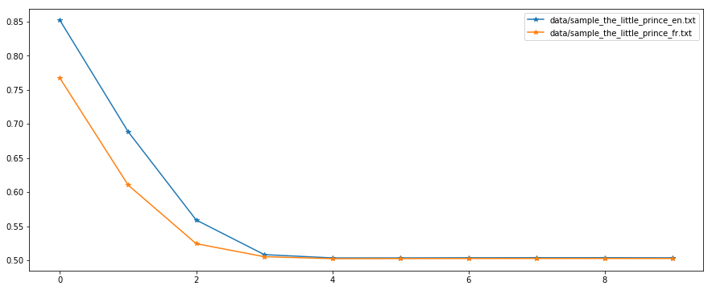

```python
for filename in filename_list:
    plt.plot(max_depth_list, compress_ratio_dict[filename], label=filename, marker='*')
plt.legend(loc=1)
```